# Intro to Google Query

This is an introduction to the Google Query language. Google Query allows you to use a subset of **SQL** functions, which makes it very versatile and powerfull. (Kind of Excel on steroids.)

The exercises introduce you to most of the basic concepts of data wrangling by using a realistic use case.

# Why do I have to learn this?

- Using a query language leaves the source data untouched, which is better for collaboration.
- Once the code has been written, you can quickly re-do all calculations in case the source changes. This is very handy in case of regular reports like dashboards etc.
- You can use more complex operations on the data than in base Excel or Google Sheets.
- Someone else can check your rationale after you are done, leading to more reliable and valid reports.
- The concepts are mostly the same in most modern applications. If you get this, the step to SQL is small. If you get the concepts, you will easily pick up the same ideas in data-wrangling packages like dplyr.
- Once the data is very big, your standard Excel will not cut it anymore.

# OK, I am convinced, so how does it work?

In essence it is like writing an Excel function.

The basic function syntax is: `=query(source_data,"query expression")`

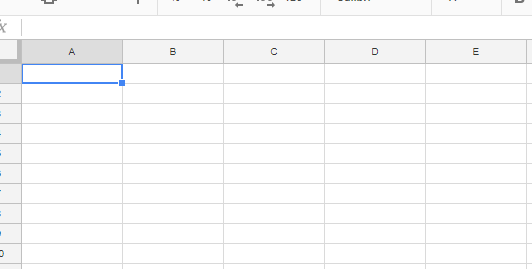

# Let`s get started: Accessing the data

You can find the Google sheet with the data here: https://docs.google.com/spreadsheets/d/103_4LZpgDLvwlh3Lm0mu03bhyTCK1SxA2F19lKElN04/edit?usp=sharing

Copy and paste this data into a new google sheet.

# Background information over the assingnment:

You have been hired to help with an analysis problem at an university:

The information from your client:

*“The dataset you see gives you the enrollment history of every single student who enrolled into one of our masters at our university. What I want to know is how long students take to finish their study. I also want to know how many of the students drop-out of the study and how many of them finish with a degree. I want to know this for students for each year from 2010/2011 till the 2016/2017 cohort.”*

Some extra background over the variables:

**ID**: This is the anonymized students ID  
**Career:** This encodes whether the student is enrolled in a bachelor (10) or a masters program (15).  
**Description:** This is the name of the type of study. **StartDate:** This is the date of enrollment for each entry. **ExamDate:** This is the date an examination (e.g. masters or bachelors thesis) was registered for the specific entry.  
**OutDate:** This is the date we registered the student de-enrolling.  
**EndDate:** This Date marks the end of the term the student is enrolled in. This date can be in the future for students who are still enrolled. **Studyplan:** This variable gives you some info about the type of study the student has followed. **Cohort:** This variable gives you the cohort the student falls in. It is only defined for students from 2010 to 2016 **Grade:** This variable is the grade of the student if the student has an entry under ExamDate, otherwise it is empty. **studyDescr:** If provided, this variable gives you some info about the specialization the student has chosen.

Have a good look at the data now. Does it all make sense? If not, do not worry! There will be some more explanation given along the way.

Some of the following exercises can be done by using some of the more standard functions of google sheets, like filtering or sorting. Please do not use those functions for the exercises. The whole point is to learn a new, more abstract and powerfull way to look at your data.

# Syntax

As already mentioned, the basic syntax of a query is:

`=query(source_data,"query expression")`

**source_data**  
This is referring to the source you want the query to operate on. `=QUERY(Rawdata!A:H,"query expression")` would execute the query expression on each entry in the worksheet Rawdata from column A to column H. Have a look here if you are a bit rusty with excel source references:

https://support.office.com/en-us/article/Create-or-change-a-cell-reference-c7b8b95d-c594-4488-947e-c835903cebaa

Before going trough all following exercises, it is a good idea to turn your source data into a named range. This way, you can reference it by a easy to remember name. To do this, make a selection of all your data and go to **Data > Named ranges…** and give your sheet a name. You can then query by using e.g. `=QUERY(yourdataname,"query expression")`

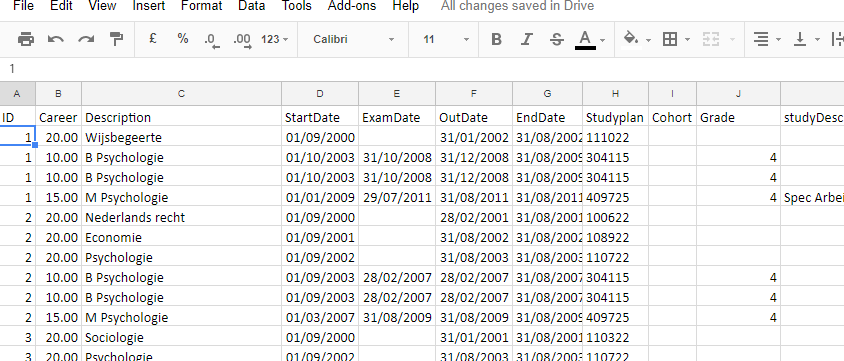

## Select

For many of the operations we want to do on data we do not need all of the columns in a dataset. To lower computatinal load and for the sake of keeping it simple, it is a good idea to only select the columns you really need. In Google Query, you can do a selection as follows:

`=query(data, "SELECT A,C,D")`

In case you want to select all columns of a dataset you can use the `*` operator.

`=query(data, "SELECT * ")`

Ready to execute your first google query? Start by making a new worksheet and type in or copy the last query into one of the cells.

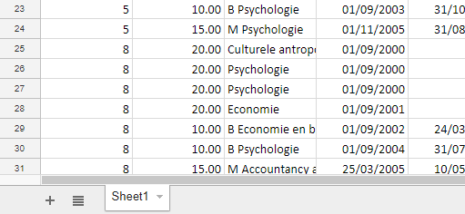

## Sort

To sort the output of a query, you can use `ORDER BY` and either `ASC` (for ascending) or `DESC` (for descending) to determine which way you want to order:

`=query(data, "SELECT A,D ORDER BY D ASC")`

`=query(data, "SELECT A,D ORDER BY D DESC")`

Try running both queries to find out the range of values in `StartDate`.

Sometimes it can be handy to order by multiple columns, which is also possible!

`=query(data, "SELECT A,D,G ORDER BY A, G ASC")`

## Filter

### Numbers and Strings

To only show a specific subset of data, we need the `WHERE` statement.

Let’s say you want to only entries that are bachelor entries. You know that this is coded by the number 10 in the variable Career.

Try:

`=query(data,"SELECT * WHERE B = 10")`

Watch out, you do need slightly different syntax for filtering numbers than for filtering for strings.

Strings need to be enclosed in single quotes.

Try:

`=query(data,"SELECT * WHERE C = 'B Psychologie'")`

It is also possible to use values stored in a cell for filtering, which can be handy for more complex queries.

To query for a cell value, you will need to put the reference to the value outside of the quotes of the query.

`"SELECT A WHERE B >= "` `&` `C2`

The ampersand before the cell reference is necessary to make clear that you want to join together the query parts.

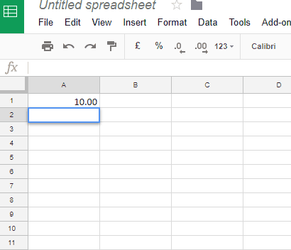

For filtering, you can use the usual operators you know from other programming languages: `<=, <, >, >=, =, !=, <>` Be aware that equality is not tested by `==` like in e.g. `R` and that `!=` and `<>` both test for inequality. To compare if a cell is blank or missing you can use `is null` or `is not null`.

Filtering for strings in a cell value is a bit more complicated.

If you cant, have a look at example 4 below and try running a query that returns all columns but filtered for `studyDescr` being `Spec Arbeids- en Org. Psych.` by using a cell.

Overview:

[output not shown]

### Dates

To filter for dates, you need to be aware of some peculiarities of Google Query. Google Query only accepts dates as a text `string` in the format `'yyyy-mm-dd'`.  
The date also has to be preceded by the identifier `date`.

A query for a date thus becomes:

If you want to use a date in a cell for filtering, you will have to jump trough some extra hoops! Google sheets tends to automatically convert dates you input in a cell into `date` format, whereas we need to provide the date in the query as a `string`. One approach to circumvent this problem would be to first enter your desired dates into one cell by hand and then use a function in another cell that converts the date to a string. The function you need is:

`=text(A1,"yyyy-MM-dd")`

pretty complicated, but that is the way it is :(

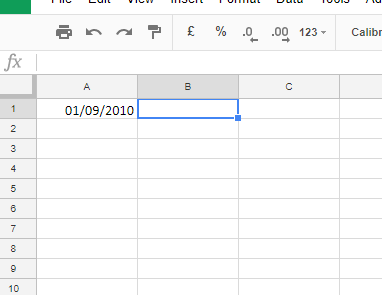

As an exercise: Try filtering for all students that have an Exam Date higher than 01-09-2014.

### AND/OR/NOT

In case you want to filter for multiple conditions, you can use `AND` and `OR`. For negation, you can use `NOT`.

Here an overview:

[output not shown]

## Exercise 1:

- Let us start by making a query that selects only the students enrolled into the master ‘M Psychologie’ and that have started after the 01-09-2010. I would also like the data to be returned from old to new. This can all be achieved in one query.
- Make a query filtering for all students that have an Exam Date lower than 01-09-2014 and higher than 01-09-2012 by using two cells.
- Make a query filtering for all students where the variable cohort is not empty.

Give the syntax of your queries.

## Functions and grouping

Functions allow you to manipulate, aggregate, compare and combine the data in one or more columns. An example would be the `sum()` function, that returns a single value, namely the sum of all values in the rows of a column. The operator `+` also counts as a function.

The functions used in Google Query split up into three categories:

- Aggregation functions
- Scalar functions
- Arithmetic operators

all of which are slightly different.

### Aggregation functions

Aggregation functions are passed a single column, and return a single value. These type of functions can only be used for the `SELECT` and `ORDER BY` clauses, but not for `WHERE` or `GROUP BY` clauses. As an example, `"SELECT count(A)"` will return the count of elements in the A column, but `"SELECT A,B WHERE B = count(A)"` will not work. Also, aggregation functions will not work on anything but one column. `sum(A) + sum(B)` is possible, but `sum(A + B)` will not work.

Here are the functions that fall into that class with an brief explanation.

| Name | Description |
| --- | --- |
| avg() | Returns the average value of all values in the column for a group. |
| count() | Returns the count of elements in the specified column for a group. |
| max() | Returns the maximum value in the column for a group. Dates are compared with earlier being smaller, strings are compared alphabetically, with case-sensitivity. |
| min() | Returns the minimum value in the column for a group. Dates are compared with earlier being smaller, strings are compared alphabetically, with case-sensitivity |
| sum() | Returns the sum of all values in the column for a group. |

Try:

`=query(data,"SELECT max(G)")`

### Scalar functions

Scalar functions are more flexible than aggregate functions. They take one or more values and produce exactly one value as a result. These functions can be used within a query and to transform each row in a column.

Here are some examples of scalar functions:

[output not shown]

.

Try running:

`=query(data,"SELECT upper(D)")`

Be aware however, that the functions only work on appropriately formated values! You cant run e.g. the year function on a string or vice-versa

If the query returns a **#VALUE** error, got to the source data sheet and set the appropriate data format.

### Arithmetic operators

You can also use arithmetic operators (`+ - / *`) to perform mathematic operations upon anything that evaluates to single number.

Just as with the scalar and arithmetic functions, you have to keep in mind the format of the data. You can not e.g subtract a string from a number or vice versa.

Try running:

`=query(data,"SELECT J - 3")`

#### GROUP BY

Many of the functions we can run in query languages are interesting for subsets of the data. In our specific case, we are interested in values for each cohort and not for the complete dataset. That is where `GROUP BY` comes in.

`=query(data,"SELECT A, avg(B) GROUP BY C")` for example, will Select column A and the average of B, but the calculations of the average will be done for each group in C separately. Be aware that you have to place the `GROUP BY` clause after the `SELECT` and `WHERE` clause, otherwise your query will not work!

## Exercises 2:

- Write a query that gives you the average grade per student.
- Write a query that gives you the average grade per student and per studyplan.
- Write a query that gives you the min and max of StartDate.
- Write a query that calculates the difference between Start date and end date in days.

## Main exercise:

Now that you have a basic understanding of how to write queries, you can make your first little data analysis in gquery. Remember what the client wanted? A nice overview of the mean time students need to finish their master studies per cohort.

1. Let us start by creating a new worksheet with a query showing all columns but only the rows with the Studyplan 409725 and where Cohort is not empty. By lucky coincidence, there are only entries for cohorts that we are interested in (2010/2011 till 2016/2017).
2. Now we will need a way to calculate the time a student was enrolled for each entry. To do this, we can use the result of the query we just made. Use the uppermost cell of the first empty column in the current worksheet and select all columns to the left as your new source, then write a query calculating the difference between EndDate and StartDate.
3. If you have taken the time to look closely, you might have noticed that some students have multiple entries! It turns out that these students have enrolled multiple times with a break inbetween. We will need to calculate the sum of those entries for each student in order to continue. Open a new worksheet and use the data of the previous query for the new query. The result of the query should be a table with the ID, Cohort, Exam Date and the sum of the periods. Hint: You will need to take the minimum or maximum of the Cohort and the ExamDate to create this table.
4. Now you can make the table with the averages. Create a new worksheet and calculate the average study time of students that have an entry under ExamDate.
5. Finally, make another table in the same worksheet showing the count of students that have finished the study and students that have not (yet).

Congratulations! You made your first dashboard.

## Optional exercises:

Now that you are a bit warmed-up, try to do the following:

- Calculate the average time till drop-out and average time till examination.
- Calculate the standard deviation for the above values.
- Calculate the percentage of students that drop-out and students that end with an exam.
- Calculate the average grade of students per cohort.
- Make a nice dashboard showing all these parameters to your client.